# 5003 Deliverable Two

Group38

7/11/2021

```r
library(foreign)
library (dplyr)
# library(arm)
# library(psych)
library(ggplot2)
library(gridExtra)
# library(tidyr)
library(gplots)
library(ggpubr)
library(graphics)
library(data.table)
library(scales)
library(car)
# install.packages("Rtools")
# install.packages("DMwR2")
# install_github("vqv/ggbiplot")
library(devtools)
library(DMwR2)
library(ggbiplot)
library(caret)
library(pROC)
```

# Overview of the problem

```r
gun.data <- read.spss("GSS7216_R3.sav", to.data.frame = T) %>%
  dplyr::select("GUNLAW",
                "OWNGUN",
                "CHILDS",
                "SIBS",
                "AGE",
                "SEX",
                "RACE",
                "DEGREE",
                "RELIG",
                "PARTYID",
                "REGION",
                "YEAR",
                "CHILDS",
                "SIBS",
                "EDUC",
                "PAEDUC",
                "MAEDUC",
                "EARNRS",
                "TEENS",
                "ADULTS",
                "INCOME",
                "RINCOME",
                "PARTFULL",
                "SATJOB",
                "WLTHWHTS",
                "WLTHBLKS",
                "COMPUSE",
                "RACPUSH",
                "RACCHURH",
                "INTWKDYM",
                "INTWKDYH",
                "INTWKENM",
                "INTWKENH",
                "YEARVAL",
                "OLD1",
                "OLD2",
                "OLD3",
                "AGEWED", "SPEDUC", "COEDUC", "WHENHS", "WHENCOL", "HOMPOP",
                "SIZE", "DOTDATA", "DOTPEOP", "DOTTHNG", "DOTGED", "DOTSVP", "DOTPRES", "SPDOTDAT", "SPDOTPEO", "SPDOTTHN", "SPDOTGED",
                "SPDOTSVP", "SPDOTPRE", "PADOTDAT", "PADOTPEO", "PADOTTHN", "PADOTGED", "PADOTSVP", "PADOTPRE", "WEEKSWRK",
                "TVHOURS", "EMAILMIN", "EMAILHR", "WWWHR", "WWWMIN", "INTSTART", "SNSMYEAR",  "USUALHRS",
                "MOSTHRS", "LEASTHRS", "PHYSHLTH", "MNTLHLTH", "HLTHDAYS", "HURTATWK", "USETECH", "WEIGHT", "HEIGHT", "NTWKHARD", "MISSWORK", "EXTRAYR",
                "VALGIVEN", "COLSCINM", "VISNHIST", "VISZOO", "VISSCI", "REALINC", "REALRINC", "CONINC", "CONRINC", "WORDSUM",
                "SEI10", "SEI10EDUC", "SEI10INC", "PASEI10", "PASEI10EDUC", "PASEI10INC", "MASEI10", "MASEI10EDUC", "MASEI10INC", "SPSEI10", "SPSEI10EDUC",
                "SPSEI10INC", "PRESTIGE", "PRESTG80", "PRESTG10", "PRESTG105PLUS", "SPPRES", "SPPRES80", "SPPRES10", "SPPRES105PLUS", "COPRES10", "PAPRES16",
                "PAPRES80", "PAPRES10", "PAPRES105PLUS", "MAPRES80", "MAPRES10", "MAPRES105PLUS")
```

```
## re-encoding from CP1252
```

```r
gun.data <- gun.data[complete.cases(gun.data[,"GUNLAW"]),] # delete NA value in GUNLAW column
```

# Dataset description

Since the original data set has more than 5000 features, we selected 119 features related to gun control. In addition, when we look at the proportion of missing value in the present data set, there are many attributes have more than 90% missing value, meanwhile, the original dataset has 55% missing value. Because these features does not have enough data to build the model, and it is not suitable to impute these missing value, in this case, we deleted the columns which contains over 50% missing value in order to improve our model prediction performance.

```r
# Miss <- function(x){
#   sum(is.na(x))/length(x)* 100
#   }
# apply(gun.data, 2, Miss)

flag <- apply(gun.data, 2, function(x) sum(is.na(x))/length(x)* 100 <= 50)
gun <- gun.data[, which(flag)]

#apply(gun, 2, Miss)

original_precentage_missing = (sum(is.na(gun.data))/prod(dim(gun.data)))*100
original_precentage_missing
```

```
## [1] 55.06203
```

```r
precentage_missing = (sum(is.na(gun))/prod(dim(gun)))*100
precentage_missing
```

```
## [1] 12.72455
```

# Feature engineering

## Feature selection

For the missing value, due to degree attributes only has 0.29 missing value, then we delete the related missing value samples. For the missing value of income and rincome features, we deleted the related rows as well because these people does not answer an income range and we could not just determine as undecided. For other missing value in the categorical attributes, we used undecided or other to replace NA in order to respect respondent’s choice. Finally, the data set we would use includes 22549 rows and 41 columns with 6.3% missing value. The method we deal with missing value is using KNN for filling in missing value.

```r
#lapply(gun, function(x) levels(x))
gun <- gun[complete.cases(gun[,c("DEGREE", "INCOME", "RINCOME")]),]

gun$CHILDS <- recode(gun$CHILDS, "'EIGHT OR MORE' = 8")
gun$AGE <- recode(gun$AGE, "'89 OR OLDER' = 89")
gun$EARNRS <- recode(gun$EARNRS, "'EIGHT OR MORE' = 8")
gun$TEENS <- recode(gun$TEENS, "'8 OR MORE' = 8")
gun$ADULTS <- recode(gun$ADULTS, "'8 OR MORE' = 8")
gun$OLD1 <- recode(gun$OLD1, "'97 or older' = 97")
gun$OLD2 <- recode(gun$OLD2, "'97 or older' = 97")
gun$OWNGUN <- recode(gun$OWNGUN, "NA = 'undecided'")
gun$PARTYID <- recode(gun$PARTYID, "NA = 'undecided'")
gun$SATJOB <- recode(gun$SATJOB, "NA = 'undecided'")
gun$RELIG <- recode(gun$RELIG, "NA = 'OTHER'")

gun$CHILDS <- as.numeric(as.character(gun$CHILDS))
gun$SIBS <- as.numeric(as.character(gun$SIBS))
gun$AGE <- as.numeric(as.character(gun$AGE))
gun$EDUC <- as.numeric(as.character(gun$EDUC))
gun$PAEDUC <- as.numeric(as.character(gun$PAEDUC))
gun$MAEDUC <- as.numeric(as.character(gun$MAEDUC))
gun$EARNRS <- as.numeric(as.character(gun$EARNRS))
gun$TEENS <- as.numeric(as.character(gun$TEENS))
gun$ADULTS <- as.numeric(as.character(gun$ADULTS))
gun$OLD1 <- as.numeric(as.character(gun$OLD1))
gun$OLD2 <- as.numeric(as.character(gun$OLD2))
gun$SPEDUC <- as.numeric(as.character(gun$SPEDUC))
gun$HOMPOP <- as.numeric(as.character(gun$HOMPOP))
gun$SIZE <- as.numeric(as.character(gun$SIZE))
gun$TVHOURS <- as.numeric(as.character(gun$TVHOURS))
gun$REALINC <- as.numeric(as.character(gun$REALINC))
gun$REALRINC <- as.numeric(as.character(gun$REALRINC))
gun$CONINC <- as.numeric(as.character(gun$CONINC))
gun$CONRINC <- as.numeric(as.character(gun$CONRINC))
gun$SEI10 <- as.numeric(as.character(gun$SEI10))
gun$SEI10EDUC <- as.numeric(as.character(gun$SEI10EDUC))
gun$SEI10INC <- as.numeric(as.character(gun$SEI10INC))
gun$PASEI10 <- as.numeric(as.character(gun$PASEI10))
gun$PASEI10EDUC <- as.numeric(as.character(gun$PASEI10EDUC))
gun$PASEI10INC <- as.numeric(as.character(gun$PASEI10INC))
gun$PRESTG10 <- as.numeric(as.character(gun$PRESTG10))
gun$PRESTG105PLUS <- as.numeric(as.character(gun$PRESTG105PLUS))
gun$PAPRES10 <- as.numeric(as.character(gun$PAPRES10))
gun$PAPRES105PLUS <- as.numeric(as.character(gun$PAPRES105PLUS))
# using knn for filling in missing value
gun <- knnImputation(gun)
anyNA(gun)
```

```
## [1] FALSE
```

```r
print(paste("any missing value? : ",anyNA(gun)))
```

```
## [1] "any missing value? :  FALSE"
```

## PCA Dimensional visualization

From the output we find that PC1 explains 22% of the variance, PC2 explains 11% and so on. We find that the first 20 components explain approximately 90% of the variance. As shown in the PCA output below, SIBS, RACE RELIG and TVHOURS contribute to the most part of PCA1 while PRESTG10, RINCOME contribute to most part of PCA2.

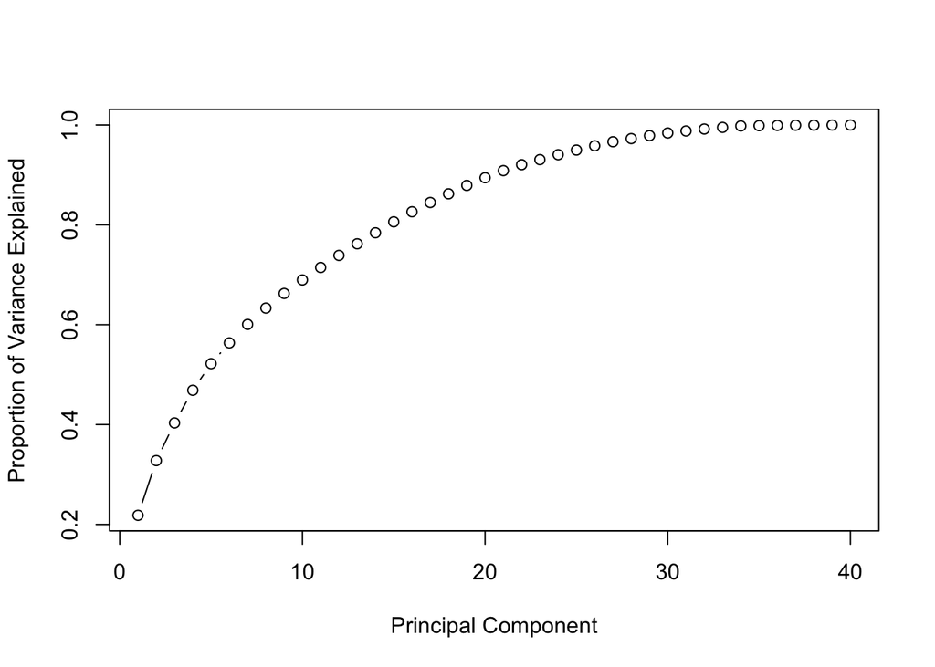

```r
# Convert categorical variables to numeric in R
gun_numeric <- gun
must_convert<-sapply(gun_numeric,is.factor)
M2<-sapply(gun_numeric[,must_convert],unclass)
gun_numeric <-cbind(gun_numeric[,!must_convert],M2)
gun_numeric$GUNLAW <- gun$GUNLAW
# Use PCA to do Dimensional reduction link:https://www.datavedas.com/dimensionality-reduction-in-r/

gun_numeric_withoutlabel <- subset(gun_numeric, select = -c(GUNLAW))

gunlaw_label <- factor(gun_numeric$GUNLAW) # Get GUNLAW as label data

pca_scaled <- prcomp(gun_numeric_withoutlabel, scale. = TRUE) # Perform PCA analysis

loadings <- as.data.frame(pca_scaled$x) # Generate PCA Loadings

Matrix <- pca_scaled$rotation # Generate Loading Matrix

std_dev <- pca_scaled$sdev

pr_comp_var <- std_dev^2 # Variance explained by each Principal Component

prop_var_ex <- pr_comp_var/sum(pr_comp_var)# Ratio of Variance explained by each component

plot(cumsum(prop_var_ex), xlab = "Principal Component",ylab = "Proportion of Variance Explained",type = "b")
```

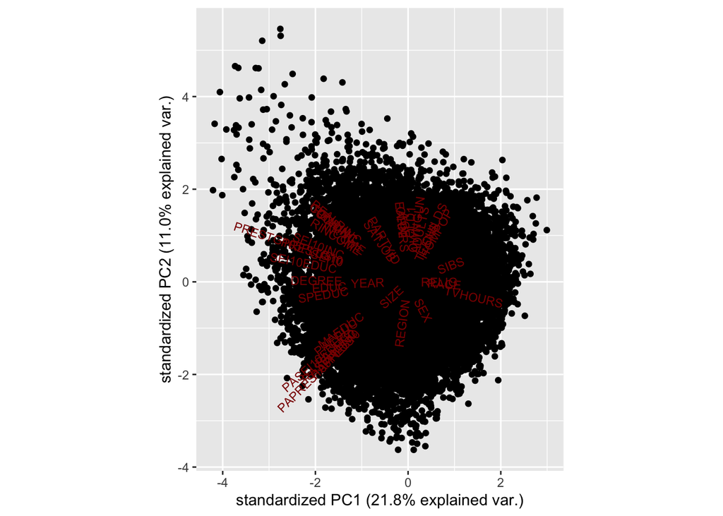

```r
ggbiplot(pca_scaled)
```

# Classification algorithms used ## Logistic Regression In the process of logistic regression, the preprocessed dataset derived from Gun Numeric is divided into 70% training set and 30% test set. Then the training set is segmented. After training model, we use the model to predict the test set and present in a confusion matrix compared with its ground truth (label).

As the number of label class in our dataset is imbalance, we choose F1 score and Kappa to evaluate the model precision. F-measure score is a new single index that combines accuracy rate and applicant rate. The success rate can only be obtained if both the accuracy rate and the evaluation rate can be seen. Kappa is another to evaluate the degree of consistency, which is between 0 and 1. The greater the value, the greater the degree of consistency. Therefore, the larger the value of kappa is, the better model is. In this model, the F1-score is 0.36 and Kappa is -0.04, which means the logistic regression model is not good using this dataset.

Area Under Curve (AUC) under ROC curve is a measure of the accuracy of a quantitative diagnostic test. The higher the AUC, the better the performance of the model at identifying between positive and negative classes.When measuring the AUC for the ROC, the ROC and AUC of the perfect classifier was equal to 1, while that of the pure random classifier was equal to 0.5. From ROC graph, we can see that area under the curve for logistic regression model is 0.4591.

```r
#Logistic Regression

set.seed(123)
gun_numeric <- data.frame(gun_numeric)
inTrain <- createDataPartition(gun_numeric$GUNLAW, p = 0.7)[[1]] # Training set Test set 7:3
guntrain <- gun_numeric[ inTrain, ]
guntest  <- gun_numeric[-inTrain, ]


glm.fit = glm((as.factor(GUNLAW)) ~ CHILDS + YEAR + EARNRS + OLD1 + HOMPOP + SIZE + SEI10 + SEI10INC + PASEI10 +
    PASEI10INC + PRESTG105PLUS + PAPRES10 + OWNGUN +
    SEX + RACE + DEGREE + RELIG + REGION + INCOME, data= guntrain,family=binomial(link="logit"))# Generate models from training data

n=nrow(guntrain)# The number of rows of training data, that is, the number of samples

p=predict(glm.fit,guntest)# Use the model to predict the test data
p=exp(p)/(1+exp(p))# Compute the dependent variable
guntest$GUNLAW_predicted = 1*(p>0.5)# Add a column to test data, that is, the prediction of GUNLAW. P >0.5, the predicted value is 1

true_value = guntest[,31]
predict_value = guntest[,42]# Take out columns 31 and 42

true_value= ifelse(true_value=='FAVOR',1,0)
# F1 score, kappa score
lr.confusion <- caret::confusionMatrix(as.factor(true_value),as.factor(predict_value))
lr.confusion
```

```
## Confusion Matrix and Statistics
##
##           Reference
## Prediction    0    1
##          0 1447  169
##          1 5031  117
##
##                Accuracy : 0.2312
##                  95% CI : (0.2212, 0.2415)
##     No Information Rate : 0.9577
##     P-Value [Acc > NIR] : 1
##
##                   Kappa : -0.0403
##
##  Mcnemar's Test P-Value : <2e-16
##
##             Sensitivity : 0.22337
##             Specificity : 0.40909
##          Pos Pred Value : 0.89542
##          Neg Pred Value : 0.02273
##              Prevalence : 0.95772
##          Detection Rate : 0.21393
##    Detection Prevalence : 0.23891
##       Balanced Accuracy : 0.31623
##
##        'Positive' Class : 0
##
```

```r
print(paste0(lr.confusion[["byClass"]][["F1"]], " is F1 score"))
```

```
## [1] "0.357548801581418 is F1 score"
```

```r
print(paste0(lr.confusion[["overall"]][["Kappa"]], " is Kappa"))
```

```
## [1] "-0.0402792943818151 is Kappa"
```

```r
# ROC
lr.roc <- roc(true_value,predict_value)
```

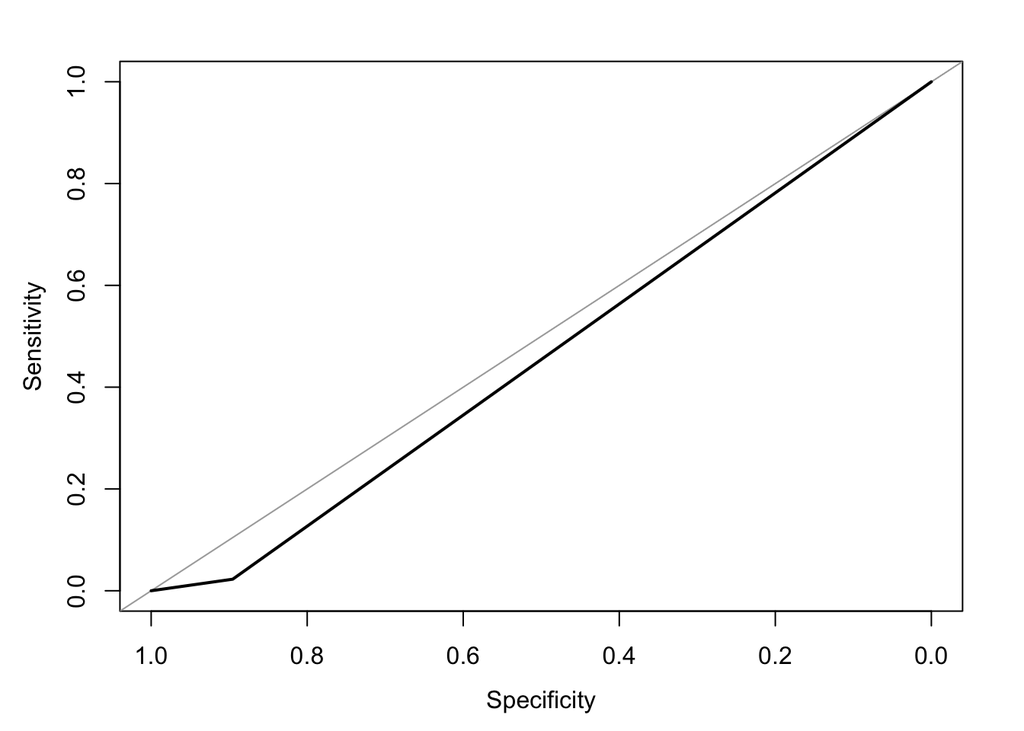

```r
plot.roc(lr.roc, asp=NA)
```

```r
# AUC
auc(lr.roc)
```

```
## Area under the curve: 0.4591
```

## KNN

In the process of KNN classification, in order to find the optimal Kappa value, we set k=1 to 10 to tune and then select the model with the best performance according to the maximum Kappa. We also used 10-fold cross validation to train the model in order to get more accurate parameter.

The F1-score is 0,81 and Kappa value is 0.031. The following line graph shows the relationship of kappa value and the value of K. It is clear to see when K equals to 3, kappa value is the highest among k=1 to 10. From ROC graph, we can see that area under the curve for KNN model is 0.5195.

```r
set.seed(123)
knn.model <- train(GUNLAW ~ . , data = guntrain, method = "knn",
                   trControl = trainControl(method = "cv", number = 10, savePredictions = "all", classProbs = TRUE),
                   tuneGrid = expand.grid(k = c(1:10)),
                   metric = "Kappa")
knn.model
```

```
## k-Nearest Neighbors
##
## 15785 samples
##    40 predictor
##     2 classes: 'FAVOR', 'OPPOSE'
##
## No pre-processing
## Resampling: Cross-Validated (10 fold)
## Summary of sample sizes: 14206, 14207, 14207, 14207, 14207, 14206, ...
## Resampling results across tuning parameters:
##
##   k   Accuracy   Kappa
##    1  0.6409858  0.025259049
##    2  0.6382620  0.015574936
##    3  0.6897037  0.029379324
##    4  0.6861559  0.017644243
##    5  0.7123203  0.024345150
##    6  0.7103575  0.013834555
##    7  0.7255611  0.012234451
##    8  0.7256246  0.014382760
##    9  0.7351264  0.008298173
##   10  0.7370906  0.011758831
##
## Kappa was used to select the optimal model using the largest value.
## The final value used for the model was k = 3.
```

```r
knn.pred <- predict(knn.model, newdata = guntest)

# F1 score, kappa score
knn.confusion <- caret::confusionMatrix(knn.pred, guntest$GUNLAW)
knn.confusion
```

```
## Confusion Matrix and Statistics
##
##           Reference
## Prediction FAVOR OPPOSE
##     FAVOR   4372   1328
##     OPPOSE   776    288
##
##                Accuracy : 0.6889
##                  95% CI : (0.6778, 0.7)
##     No Information Rate : 0.7611
##     P-Value [Acc > NIR] : 1
##
##                   Kappa : 0.0311
##
##  Mcnemar's Test P-Value : <2e-16
##
##             Sensitivity : 0.8493
##             Specificity : 0.1782
##          Pos Pred Value : 0.7670
##          Neg Pred Value : 0.2707
##              Prevalence : 0.7611
##          Detection Rate : 0.6464
##    Detection Prevalence : 0.8427
##       Balanced Accuracy : 0.5137
##
##        'Positive' Class : FAVOR
##
```

```r
print(paste0(knn.confusion[["byClass"]][["F1"]], " is F1 score"))
```

```
## [1] "0.806047197640118 is F1 score"
```

```r
print(paste0(knn.confusion[["overall"]][["Kappa"]], " is Kappa"))
```

```
## [1] "0.0311271161885839 is Kappa"
```

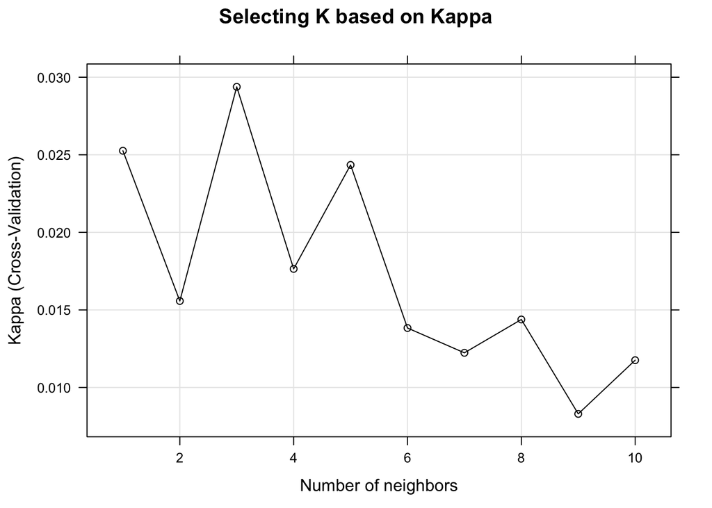

```r
trellis.par.set(caretTheme())
plot(knn.model, metric = "Kappa", xlab="Number of neighbors", main="Selecting K based on Kappa")
```

```r
# ROC
knn.roc <- roc(knn.model$pred$obs,knn.model$pred$FAVOR)
```

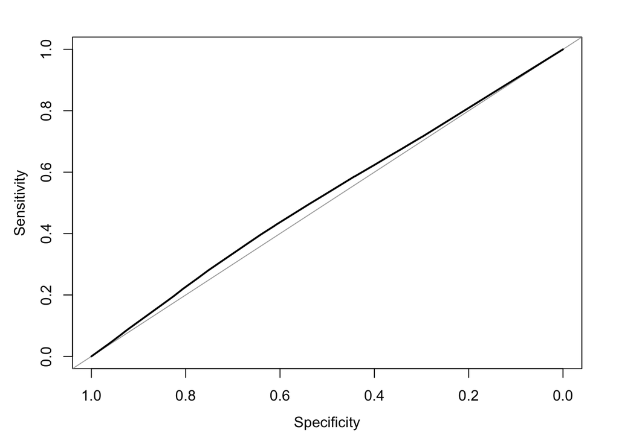

```r
plot.roc(knn.roc, asp=NA)
```

```r
# AUC
auc(knn.roc)
```

```
## Area under the curve: 0.5195
```

## LDA

In the process of LDA classification, we firstly set seed make sure the result always kept the same. We also choose folds at 10 for cross validation, For LDA model cross validation also plays the parameter tuning role. Thus, we have the linear discriminate analysis model ready.

As shown in confusion matrix below, Higher the F1-score better the model, meanwhile we should consider if the generalization of the model is acceptable. In this case, for LDA model we have the F1 score as 0.86 and the Kappa value is 0.12. From ROC graph, we can see that area under the curve for LDA model is 0.7036 which shows the highly distingusion between positive class and negative class.

```r
set.seed(123)

lda.model <- train(GUNLAW ~ . , data = guntrain, method = "lda",
                   trControl = trainControl(method = "cv", number = 10, savePredictions = "all", classProbs = TRUE))
lda.model
```

```
## Linear Discriminant Analysis
##
## 15785 samples
##    40 predictor
##     2 classes: 'FAVOR', 'OPPOSE'
##
## No pre-processing
## Resampling: Cross-Validated (10 fold)
## Summary of sample sizes: 14206, 14207, 14207, 14207, 14207, 14206, ...
## Resampling results:
##
##   Accuracy   Kappa
##   0.7613581  0.1033531
```

```r
lda.pred <- predict(lda.model, newdata = guntest)

# F1 score, kappa score
lda.confusion <- caret::confusionMatrix(lda.pred, guntest$GUNLAW)
lda.confusion
```

```
## Confusion Matrix and Statistics
##
##           Reference
## Prediction FAVOR OPPOSE
##     FAVOR   4978   1422
##     OPPOSE   170    194
##
##                Accuracy : 0.7646
##                  95% CI : (0.7543, 0.7747)
##     No Information Rate : 0.7611
##     P-Value [Acc > NIR] : 0.2518
##
##                   Kappa : 0.1185
##
##  Mcnemar's Test P-Value : <2e-16
##
##             Sensitivity : 0.9670
##             Specificity : 0.1200
##          Pos Pred Value : 0.7778
##          Neg Pred Value : 0.5330
##              Prevalence : 0.7611
##          Detection Rate : 0.7360
##    Detection Prevalence : 0.9462
##       Balanced Accuracy : 0.5435
##
##        'Positive' Class : FAVOR
##
```

```r
print(paste0(lda.confusion[["byClass"]][["F1"]], " is F1 score"))
```

```
## [1] "0.862140630412193 is F1 score"
```

```r
print(paste0(lda.confusion[["overall"]][["Kappa"]], " is Kappa"))
```

```
## [1] "0.118529122468786 is Kappa"
```

```r
# ROC
lda.roc <- roc(lda.model$pred$obs,lda.model$pred$FAVOR)
```

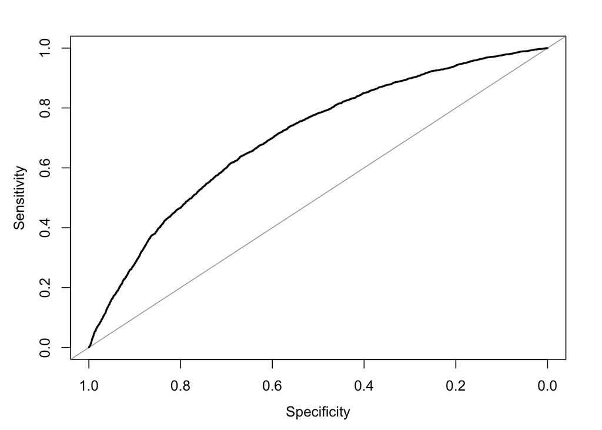

```r
plot.roc(lda.roc, asp=NA)
```

```r
# AUC
auc(lda.roc)
```

```
## Area under the curve: 0.7036
```

## XGBoost

In the process of XGBoost model, 10-fold cross-validation method was also used in order to perform an accurate test. The evaluation metrics that we look into are primarily the Area under curve, F1 score as well as the kappa indices. Confusion matrix were used as an indicator of visualizing the predicted value comparing to the actual.

```r
xgbGrid <-  expand.grid(nrounds = c(500,1000,1500),
                        max_depth = c(1,5,10),
                        eta = 0.01,
                        gamma = 0,
                        colsample_bytree = 0.5,
                        min_child_weight = 1,
                        subsample = 0.5)

nrow(xgbGrid)
```

```
## [1] 9
```

```r
head(twoClassSummary)
```

```
##
## 1 function (data, lev = NULL, model = NULL)
## 2 {
## 3     if (length(lev) > 2) {
## 4         stop(paste("Your outcome has", length(lev), "levels. The twoClassSummary() function isn't appropriate."))
## 5     }
## 6     requireNamespaceQuietStop("pROC")
```

```r
set.seed(123)

xgb.model <- train(GUNLAW ~ . , data = guntrain, method = "xgbTree",
                   trControl = trainControl(method = "cv", number = 10, savePredictions = "all", classProbs = TRUE, summaryFunction = twoClassSummary),
                   verbose = FALSE,
                   tuneGrid = xgbGrid,
                   metric = "ROC")
xgb.model
```

```
## eXtreme Gradient Boosting
##
## 15785 samples
##    40 predictor
##     2 classes: 'FAVOR', 'OPPOSE'
##
## No pre-processing
## Resampling: Cross-Validated (10 fold)
## Summary of sample sizes: 14206, 14207, 14207, 14207, 14207, 14206, ...
## Resampling results across tuning parameters:
##
##   max_depth  nrounds  ROC        Sens       Spec
##    1          500     0.7056045  1.0000000  0.00000000
##    1         1000     0.7152840  0.9944223  0.02412460
##    1         1500     0.7193713  0.9873458  0.06229562
##    5          500     0.7307379  0.9737762  0.12776445
##    5         1000     0.7305832  0.9603735  0.17520736
##    5         1500     0.7292239  0.9557111  0.19243541
##   10          500     0.7248657  0.9681158  0.13942150
##   10         1000     0.7221742  0.9612893  0.16062271
##   10         1500     0.7182523  0.9576263  0.16910446
##
## Tuning parameter 'eta' was held constant at a value of 0.01
## Tuning
##
## Tuning parameter 'min_child_weight' was held constant at a value of 1
##
## Tuning parameter 'subsample' was held constant at a value of 0.5
## ROC was used to select the optimal model using the largest value.
## The final values used for the model were nrounds = 500, max_depth = 5, eta
##  = 0.01, gamma = 0, colsample_bytree = 0.5, min_child_weight = 1 and
##  subsample = 0.5.
```

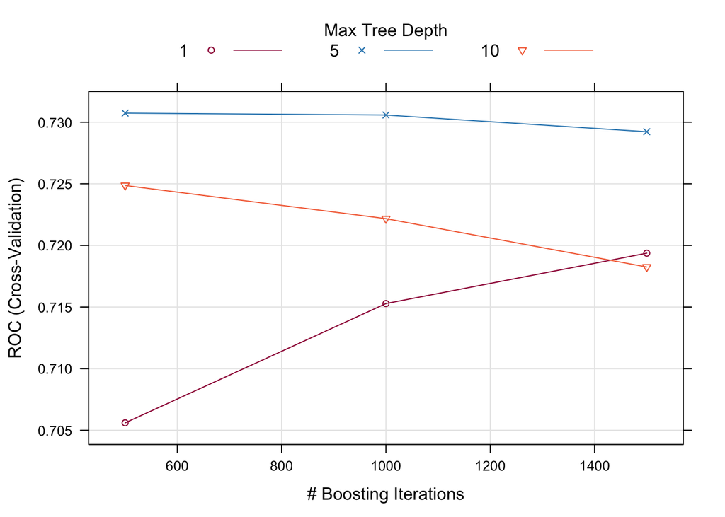

```r
trellis.par.set(caretTheme())
plot(xgb.model, metric = "ROC")
```

```r
xgb.pred <- predict(xgb.model, newdata = guntest)
# F1 score, kappa score
xgb.confusion <- caret::confusionMatrix(xgb.pred, guntest$GUNLAW)
xgb.confusion
```

```
## Confusion Matrix and Statistics
##
##           Reference
## Prediction FAVOR OPPOSE
##     FAVOR   5024   1402
##     OPPOSE   124    214
##
##                Accuracy : 0.7744
##                  95% CI : (0.7642, 0.7843)
##     No Information Rate : 0.7611
##     P-Value [Acc > NIR] : 0.005142
##
##                   Kappa : 0.1487
##
##  Mcnemar's Test P-Value : < 2.2e-16
##
##             Sensitivity : 0.9759
##             Specificity : 0.1324
##          Pos Pred Value : 0.7818
##          Neg Pred Value : 0.6331
##              Prevalence : 0.7611
##          Detection Rate : 0.7428
##    Detection Prevalence : 0.9500
##       Balanced Accuracy : 0.5542
##
##        'Positive' Class : FAVOR
##
```

```r
print(paste0(xgb.confusion[["byClass"]][["F1"]], " is F1 score"))
```

```
## [1] "0.86815275617764 is F1 score"
```

```r
print(paste0(xgb.confusion[["overall"]][["Kappa"]], " is Kappa"))
```

```
## [1] "0.148672928399167 is Kappa"
```

```r
# ROC
xgb.roc <- roc(xgb.model$pred$obs,xgb.model$pred$FAVOR)
```

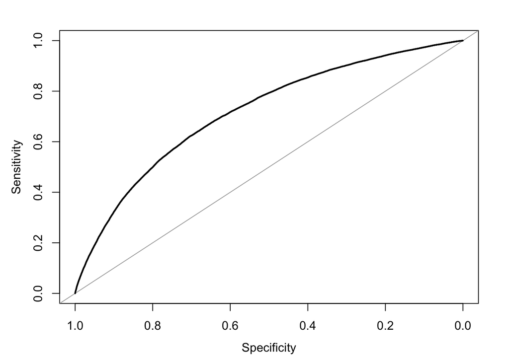

```r
plot.roc(xgb.roc, asp=NA)
```

```r
# AUC
auc(xgb.roc)
```

```
## Area under the curve: 0.7168
```

# Performance evaluation/Model comparsion

## Comparison results display

In this part, the experimental performance of four classifiers is analyzed, and the details leading to such performance differences are compared.

By summarize the results of the experiment. Logistic regression does not perform well on this data set, with a very low AUC area of only 0.4590. As the high-level data such as kappa is-0.0403, and F1score performed poorly at 0.3575. The second classifier is the KNN classifier, with an AUC area of 0.5195, and the kappa is 0.0311 and it can be seen from the distribution of the confidence interval that the model is very stable. The third model is LDA. The AUC area of this model is 0.7035. It can be seen from the confidence interval that the model is also very stable. The accuracy rate are not compared in this case as there are label imbalance with the data. The fourth model is XGboost, which has the all the highest values in F1-score at 0.87, kappa at 0.15, AUC value of 0.7167.

## Experiment results analysis

As the XGBoost achieved the highest F1-score, Kappa and the biggest proportion auc from roc plot, we finally choose it as our optimal classifier to predict people who favor or oppose the gun control law. We also summarize the characteristics of these four classifiers thourgh the experiments, so as to better select specific one classifier based on different data sets and requirements:

• XGboost XGboost model is able to perform a high training calculation with less cost. Due to the high feature dimension of the data set, XGboost can better perform classification prediction through the method of ensemble learning.

• LDA model LDA model can improve the accuracy through prior knowledge of the category, but the model has higher requirements for the distribution of data. The data distribution of this data set is relatively stable after data preprocessing, and missing and outliers are removed.

• logistic regression Logistic regression model preform fast and it is easy to apply. As is a linear classifier, so it cannot handle the correlation between features. When the feature space is large, the performance is not good. Therefore, the LR model is difficult to fully fit in our dataset, resulting in a very low accuracy rate of the model.

```r
print(paste0(lr.confusion[["byClass"]][["F1"]], " is LR F1 score"))
```

```
## [1] "0.357548801581418 is LR F1 score"
```

```r
print(paste0(lr.confusion[["overall"]][["Kappa"]], " is LR Kappa"))
```

```
## [1] "-0.0402792943818151 is LR Kappa"
```

```r
print(paste0(auc(lr.roc), " is LR auc"))
```

```
## [1] "0.45907403240324 is LR auc"
```

```r
print(paste0(knn.confusion[["byClass"]][["F1"]], " is KNN F1 score"))
```

```
## [1] "0.806047197640118 is KNN F1 score"
```

```r
print(paste0(knn.confusion[["overall"]][["Kappa"]], " is KNN Kappa"))
```

```
## [1] "0.0311271161885839 is KNN Kappa"
```

```r
print(paste0(auc(knn.roc), " is KNN auc"))
```

```
## [1] "0.519541633382079 is KNN auc"
```

```r
print(paste0(lda.confusion[["byClass"]][["F1"]], " is LDA F1 score"))
```

```
## [1] "0.862140630412193 is LDA F1 score"
```

```r
print(paste0(lda.confusion[["overall"]][["Kappa"]], " is LDA Kappa"))
```

```
## [1] "0.118529122468786 is LDA Kappa"
```

```r
print(paste0(auc(lda.roc), " is LDA auc"))
```

```
## [1] "0.70359479728682 is LDA auc"
```

```r
print(paste0(xgb.confusion[["byClass"]][["F1"]], " is XGB F1 score"))
```

```
## [1] "0.86815275617764 is XGB F1 score"
```

```r
print(paste0(xgb.confusion[["overall"]][["Kappa"]], " is XGB Kappa"))
```

```
## [1] "0.148672928399167 is XGB Kappa"
```

```r
print(paste0(auc(xgb.roc), " is XGB auc"))
```

```
## [1] "0.716794535561653 is XGB auc"
```

# Conclusion

## Summary

Our team summarized the following four points of experience from this assignment  The optimal model in this experiment is XGboasting, which F1-score is 0.87, Kappa is 0.15, and the area under curve is 0.7168.

 Understand the characteristics of different classifiers

 Understand the applicable scenarios of different classifiers

 Understand the importance of data processing to data analysis

## Potential problem

1. Due to the large number of missing values in the data set, although data preprocessing has been performed to fill in the missing values, it still has a great negative impact on the final result.
2. The amount of data in this data set is very large, and the feature dimension of the data set are also very large (41). In the case of limited computing calculate ability, it is difficult to finetune the hyperparameters to obtain a model that specifically fits the features of the data set.
3. After research and data analysis, our team found that the data set has a problem of class imbalance. Take the common binary classification problem as an example, we use other indicators to evaluate the model.

# Feature work

After this experiment, we discovered the importance of feature engineering. Good data preprocessing and feature extraction are one of the key reasons for the success of machine learning models. We will adopt more data preprocessing methods in future learning. In addition, our team only tried the application of the model, and the hyperparameter tuning part needs further enhancement. In addition, in future learning, we will try more complex models and more complex data sets, such as photo classification and scene recognition, instead of just classifying text features. This can better fit the real application scenario,

# Contribution

All members take their own responsibility and contribute equally on all aspects of the project and agree on the contribution statement.